# Quantify similarity between CVs

Joyce Hsiao

2015-10-31

**Last updated:** 2015-11-01

**Code version:** 3293fe6387e73d287ca77b4d15967416c9b9d874

## Objective

We computed similarity metrics to quantify similarity between individuals in coefficients of variation (after accounting for mean dependenc): 1) Sum-of-Squared-Deviation-from-the-Meidan (SSM), and 2) Sum-of-Absolute-Deviation-from-the-Median (SAM). We ordered genes by these metrics and described genes with high and low similarity between individual adjusted-CV.

# Per gene comparison of CVs

Joyce Hsiao

2015-10-28

**Last updated:** 2015-10-28

**Code version:** 6139907e5256d9e88a1f483576032c5a8ab86d18

## Set up

```r
library("data.table")
library("dplyr")
library("limma")
library("edgeR")
library("ggplot2")
library("grid")
<<<<<<< HEAD
library("Humanzee")
=======
>>>>>>> 62bc5a2ab71c7d07af0b00504bd53484166fd98b
theme_set(theme_bw(base_size = 12))
source("functions.R")
```

## Prepare data

Input quality single cells

```r
quality_single_cells <- read.table("../data/quality-single-cells.txt",
                                  header = TRUE,
                                  stringsAsFactors = FALSE)
str(quality_single_cells)
```

```
'data.frame':   567 obs. of  1 variable:
 $ NA19098.r1.A01: chr  "NA19098.r1.A02" "NA19098.r1.A04" "NA19098.r1.A05" "NA19098.r1.A06" ...
```

Input annotation of only QC-filtered single cells. Remove NA19098.r2

```r
anno <- read.table("../data/annotation.txt",
                    header = TRUE,
                    stringsAsFactors = FALSE)
anno_filter <- anno[ which(anno$sample_id %in% quality_single_cells[[1]]), ]
dim(anno_filter)
```

```
[1] 567   5
```

Import endogeneous gene molecule counts that are QC-filtered, CPM-normalized, ERCC-normalized, and also processed to remove unwanted variation from batch effet. ERCC genes are removed from this file.

```r
molecules_ENSG <- read.table("../data/molecules-final.txt",
                             header = TRUE, stringsAsFactors = FALSE)
stopifnot(NCOL(molecules_ENSG) == NROW(anno_filter))
```

## Import gene symbols

```r
gene_info <- read.table("../data/gene-info.txt", sep = "\t",
                        header = TRUE, stringsAsFactors = FALSE)
str(gene_info)
```

```
'data.frame':   6152 obs. of  5 variables:
 $ ensembl_gene_id   : chr  "ENSG00000000003" "ENSG00000000005" "ENSG00000000419" "ENSG00000000457" ...
 $ chromosome_name   : chr  "X" "X" "20" "1" ...
 $ external_gene_name: chr  "TSPAN6" "TNMD" "DPM1" "SCYL3" ...
 $ transcript_count  : int  3 2 7 5 10 4 12 2 13 8 ...
 $ description       : chr  "tetraspanin 6 [Source:HGNC Symbol;Acc:11858]" "tenomodulin [Source:HGNC Symbol;Acc:17757]" "dolichyl-phosphate mannosyltransferase polypeptide 1, catalytic subunit [Source:HGNC Symbol;Acc:3005]" "SCY1-like 3 (S. cerevisiae) [Source:HGNC Symbol;Acc:19285]" ...
```

Input annotation of only QC-filtered single cells. Remove NA19098.r2

```r
anno_qc <- read.table("../data/annotation-filter.txt", header = TRUE,
                   stringsAsFactors = FALSE)
is_include <- anno_qc$batch != "NA19098.r2"
anno_qc_filter <- anno_qc[which(is_include), ]
```

Import endogeneous gene molecule counts that are QC-filtered, CPM-normalized, ERCC-normalized, and also processed to remove unwanted variation from batch effet. ERCC genes are removed from this file.

```r
molecules_ENSG <- read.table("../data/molecules-final.txt", header = TRUE, stringsAsFactors = FALSE)
molecules_ENSG <- molecules_ENSG[ , is_include]
```

Input moleclule counts before log2 CPM transformation. This file is used to compute percent zero-count cells per sample.

```r
molecules_sparse <- read.table("../data/molecules-filter.txt", header = TRUE, stringsAsFactors = FALSE)

molecules_sparse <- molecules_sparse[grep("ENSG", rownames(molecules_sparse)), ]
stopifnot( all.equal(rownames(molecules_ENSG), rownames(molecules_sparse)) )
```

## Compute normalized CV

We compute squared CV across cells for each individual and then for each individual CV profile, account for mean dependency by computing distance with respect to the data-wide coefficient variation on the log10 scale.

```r
ENSG_cv <- Humanzee::compute_cv(log2counts = molecules_ENSG,
                      grouping_vector = anno_filter$individual)

ENSG_cv_adj <- Humanzee::normalize_cv(group_cv = ENSG_cv,
                            log2counts = molecules_ENSG,
                            anno = anno_filter)
```

## Compute summary measure of deviation

- Standardize the each CV vectors

Individual CV vectors are standarized for individual CV mean and coefficients of variation across genes.

```r
source("../code/cv-functions.r")

ENSG_cv <- compute_cv(log2counts = molecules_ENSG,
                      grouping_vector = anno_qc_filter$individual)

ENSG_cv_adj <- normalize_cv(group_cv = ENSG_cv,
                            log2counts = molecules_ENSG,
                            anno = anno_qc_filter)
```

## Compute summary measure of deviation

Standardize the each CV vectors

```r
df_cv <- data.frame(NA19098 = ENSG_cv_adj[[1]]$log10cv2_adj,
                    NA19101 = ENSG_cv_adj[[2]]$log10cv2_adj,
                    NA19239 = ENSG_cv_adj[[3]]$log10cv2_adj)

library(matrixStats)
df_norm <- sweep(df_cv, MARGIN = 2, STATS = colMeans(as.matrix(df_cv)), FUN = "-")
<<<<<<< HEAD
df_norm <- sweep(df_norm, MARGIN = 2, STATS = sqrt(colVars(as.matrix(df_cv))), FUN = "/")
colnames(df_norm) <- names(ENSG_cv_adj)
```

- Adj-CVs before/after standardization.

CVs are similar between individuals.

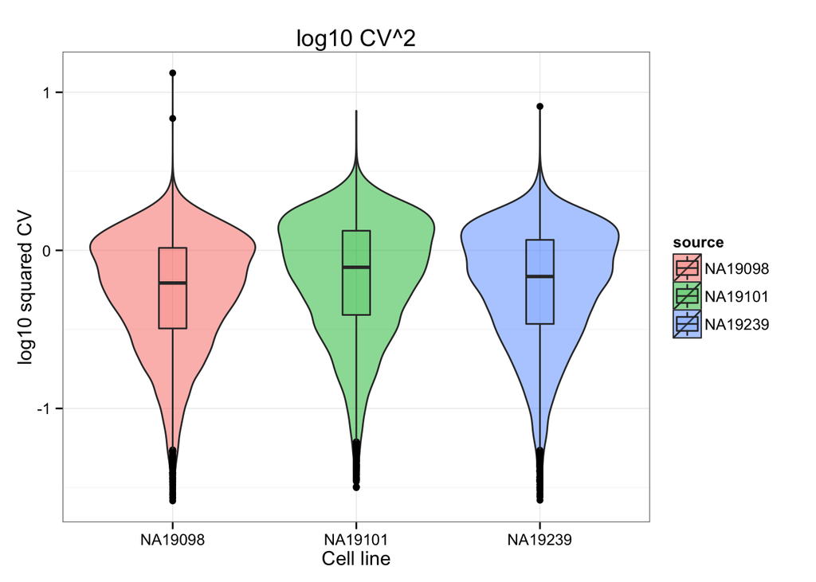

```r
ggplot(data.frame(cv = c(t(rbind( ENSG_cv_adj[[1]]$cv,
                                  ENSG_cv_adj[[2]]$cv,
                                  ENSG_cv_adj[[3]]$cv) )),
                  source = factor(rep(colnames(df_cv), each = dim(df_cv)[1]) )),
        aes(x = source, y = log10(cv^2), fill = source) ) +
  geom_violin(alpha = .5) + geom_boxplot(alpha = .2, width = .2) +
  xlab ("Cell line") + ylab("log10 squared CV") +
  ggtitle("log10 CV^2")
```

The distributions of the adjusted squared CVs are not the same in their medians. This may cause an unfair comparison of the adj. CV^2 scores between individuals.

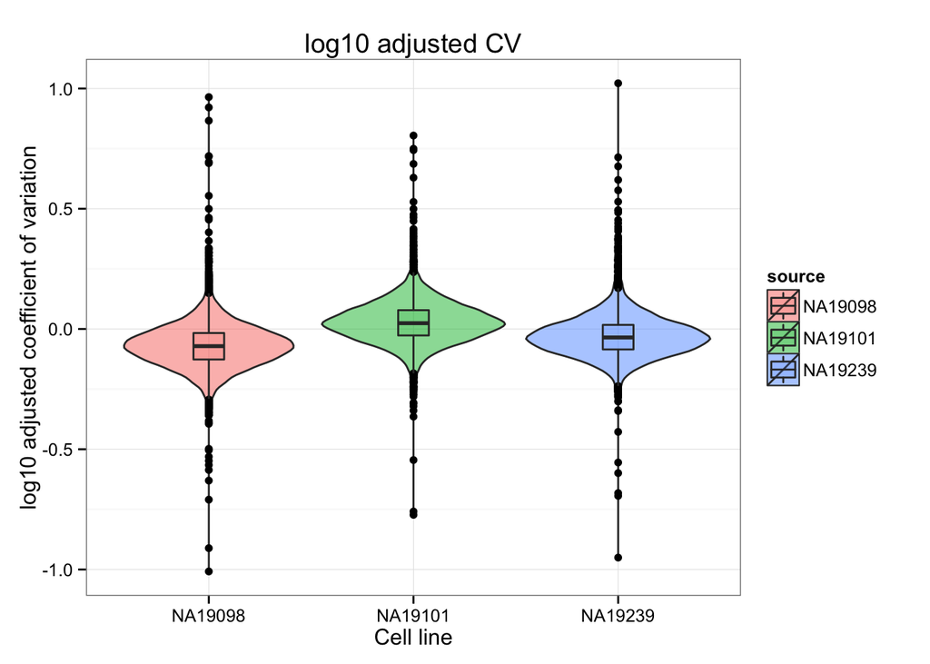

```r
ggplot(data.frame(adj_cv = c(t(rbind( ENSG_cv_adj[[1]]$log10cv2_adj,
                                  ENSG_cv_adj[[2]]$log10cv2_adj,
                                  ENSG_cv_adj[[3]]$log10cv2_adj) )),
                  source = factor(rep(colnames(df_cv), each = dim(df_cv)[1]) )),
        aes(x = source, y = adj_cv, fill = source) ) +
  geom_violin(alpha = .5) + geom_boxplot(alpha = .2, width = .2) +
  xlab ("Cell line") + ylab("log10 adjusted coefficient of variation") +
  ggtitle("log10 adjusted CV")
```

We normlized the log10 adj. CV^2 by standardizing indivdual CVs over the mean and standard deviation across genes. Note the change in CV distribution from log10 adj CV^2 to normalized log10 adj CV^2. After accounting for differences in variability of the log10 adj. CV62, we observed that NA19098 spans an obviously smaller range of normalized adj CV^2 values than the other two cell lines, probably a consequence of the small number of cells in NA19098 (n = 141) compared to the others (NA19101: 201 cells; NA19239: 225 cells).

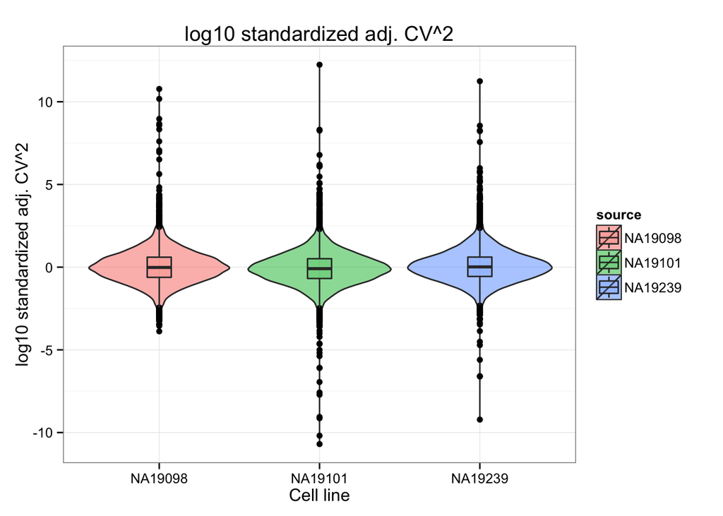

```r
ggplot(data.frame(norm_cv = c(t( df_norm )),
                  source = factor(rep(colnames(df_cv), each = dim(df_cv)[1]) )),
        aes(x = source, y = norm_cv, fill = source) ) +
  geom_violin(alpha = .5) + geom_boxplot(alpha = .2, width = .2) +
  xlab ("Cell line") + ylab("log10 standardized adj. CV^2") +
  ggtitle("log10 standardized adj. CV^2")
```

- Compute metrics for quantifying similarity between the three individual coefficients of variation.

```r
library(matrixStats)
df_norm <- as.data.frame(df_norm)
df_norm$squared_dev <- rowSums( ( df_norm - rowMedians(as.matrix(df_norm)) )^2 )
df_norm$abs_dev <- rowSums(abs( df_norm - rowMedians(as.matrix(df_norm)) ))
```

## Compare the two metrics

Box plots

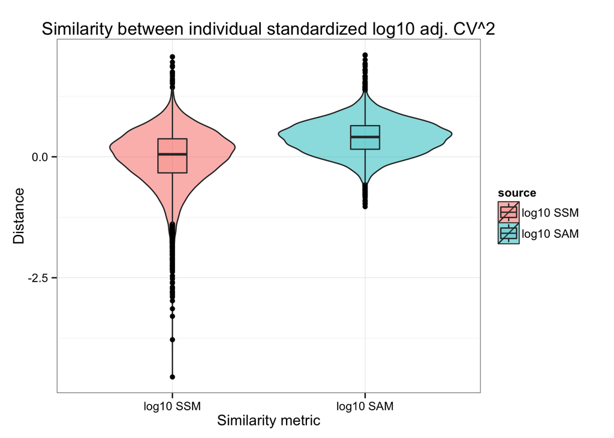

```r
ggplot(data.frame(dist = c(unlist(df_norm$squared_dev),
                           unlist(df_norm$abs_dev)),
                  source = factor(rep(c(1:2), each = dim(df_norm)[1]),
                                  labels = c("log10 SSM", "log10 SAM"))),
       aes(x = source, y = log10(dist), fill = source)) +
  geom_violin(alpha = .5) + geom_boxplot(alpha = .2, width = .2) +
  xlab("Similarity metric") + ylab("Distance") +
  ggtitle("Similarity between individual standardized log10 adj. CV^2")
```

Density plots

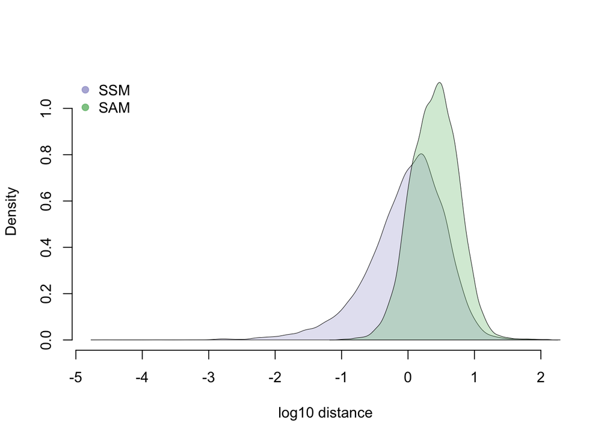

```r
library(broman)
crayon <- brocolors("crayon")
library(scales)

dens <- list( density(log10(df_norm$squared_dev)),
              density(log10(df_norm$abs_dev)) )
names(dens) <- c("SSM", "SAM")
xlims <- c(range( sapply(dens, "[[", 1) ) )
ylims <- c(0, max( sapply(dens, "[[", 2) ) )

par(mfrow = c(1,1))
plot(0, pch = "",
     xlab = "log10 distance", main = "",
     ylab = "Density", axes = F, xlim = xlims, ylim = ylims)
axis(1); axis(2)
polygon(dens[[1]], col = alpha( crayon["Blue Bell"], .3), lwd = .5 )
polygon(dens[[2]], col = alpha( crayon["Fern"], .3), lwd = .5)
legend("topleft", legend = c("SSM", "SAM"), bty="n",
       pch = 19, cex = 1,
       col = c(alpha( crayon["Blue Bell"], .8),
               alpha( crayon["Fern"], .8) ) )
```

Gene rankings based on SSM (Sum-of-Squared-Deviation-from-the-Median) and SAM (Sum-of-Absolute-Deviation-from-the-Median).

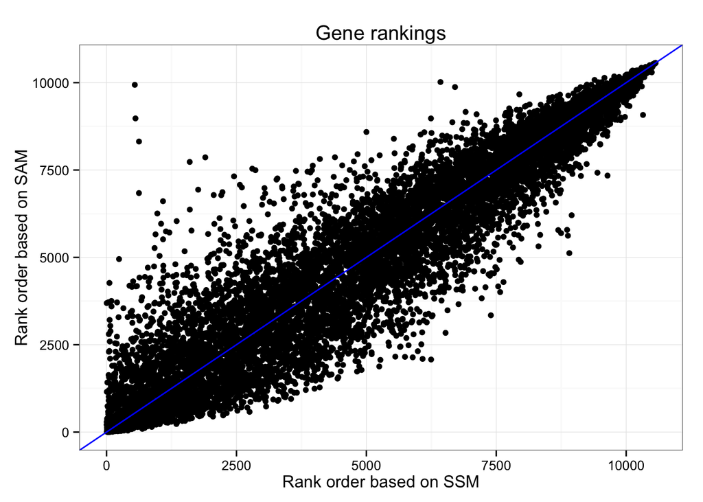

```r
ggplot(df_norm,
       aes(x = rank(squared_dev), y = rank(abs_dev)) ) +
  geom_point() + geom_abline(col = "blue") +
  ggtitle("Gene rankings") +
  xlab("Rank order based on SSM") +
  ylab("Rank order based on SAM")
```

*Look at the gene with low ranking in SSM (small difference) but high ranking in SAM (large difference).

```r
library(broman)
crayon <- brocolors("crayon")
library(scales)

index <- rank(df_norm$squared_dev) < 1000 & rank(df_norm$abs_dev) > 8000
sum(index)
```

```
[1] 3
```

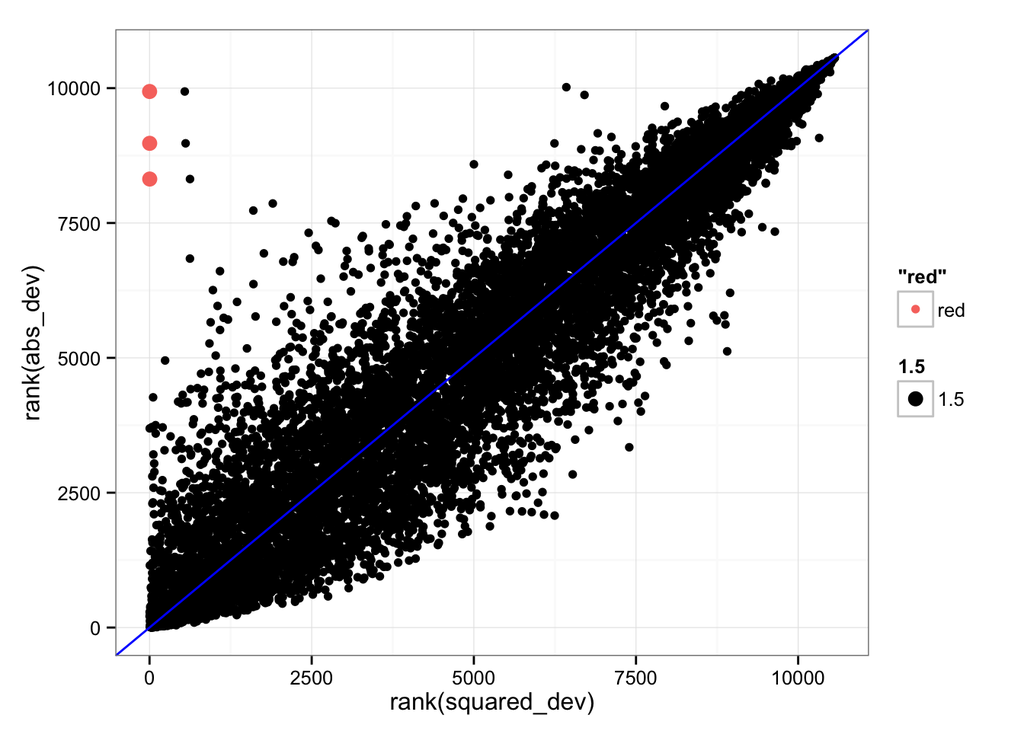

```r
ggplot(df_norm,
       aes(x = rank(squared_dev), y = rank(abs_dev)) ) +
  geom_point() + geom_abline(col = "blue") +
#   ggtitle("Gene rankings") +
#   xlab("Rank order based on SSM") +
#   ylab("Rank order based on SAM") +
  geom_point(data = data.frame(x = rank(df_norm$squared_dev[which(index)]),
                               y = rank(df_norm$abs_dev)[which(index)]),
             aes(x = x, y = y, col = "red", cex = 1.5) )
```

```r
# Find gene symbol
gene_ENSG <- rownames(molecules_ENSG)[which(index)]
gene_name <- sapply(gene_ENSG, function(per_gene) {
    if ( sum(gene_info$ensembl_gene_id == per_gene) == 0 ) {
      return(NA)
    }
    if ( sum(gene_info$ensembl_gene_id == per_gene) > 0  ) {
      gene_info$external_gene_name[which(gene_info$ensembl_gene_id == per_gene) ]
    }
})
gene_name
```

```
ENSG00000108518 ENSG00000269028 ENSG00000198840
             NA     "MTRNR2L12"        "MT-ND3"
```

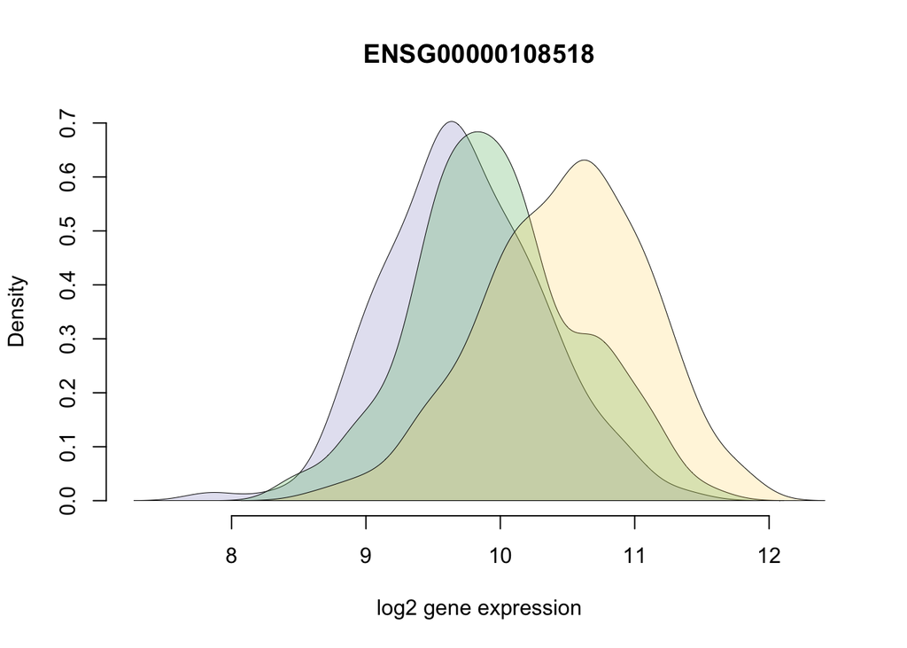

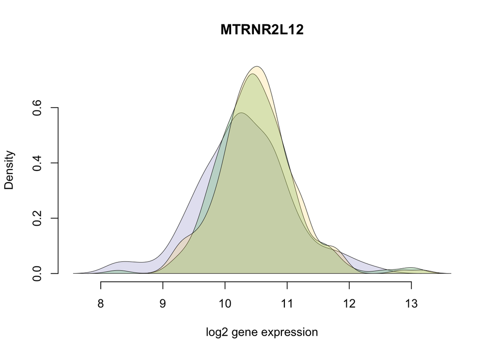

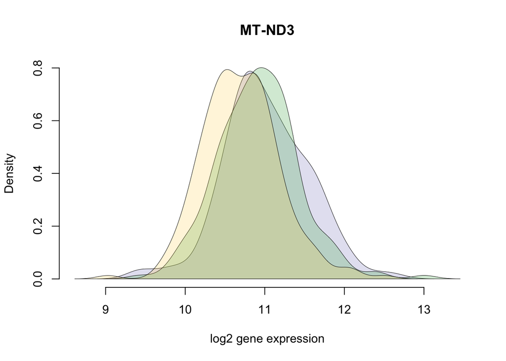

```r
# Plot density for individual gene expression
for (i in 1: length(gene_name)) {

  dens <- lapply(1:3, function(ii_individual) {
     density( unlist(molecules_ENSG[ which(index)[i],
          anno_filter$individual == unique(anno_filter$individual)[ii_individual]]) )
    })
  names(dens) <- unique(anno_filter$individual)
  xlims <- c(range( sapply(dens, "[[", 1) ) )
  ylims <- c(0, max( sapply(dens, "[[", 2) ) )

  par(mfrow = c(1,1))
  plot(0, pch = "",
       xlab = "log2 gene expression", main = "",
       ylab = "Density", axes = F, xlim = xlims, ylim = ylims)
  axis(1); axis(2)
  polygon(dens[[1]], col = alpha( crayon["Blue Bell"], .3), lwd = .5 )
  polygon(dens[[2]], col = alpha( crayon["Fern"], .3), lwd = .5)
  polygon(dens[[3]], col = alpha( crayon["Sunglow"], .2), lwd = .5 )
  title( ifelse(is.na(gene_name[i]), names(gene_name)[i], gene_name[i] ) )
}
```

Print out CV values. Recall that these are standardized values (z-scores); hence, vlaues outside of mean +/- standard deviation are quite large.

```r
df_norm[which(index), ]
```

```
       NA19098  NA19101  NA19239 squared_dev  abs_dev
4081  4.742968 4.486301 4.301995  0.09984679 4.827428
7156  8.553986 8.263651 8.222342  0.08600078 8.509293
10152 5.704659 5.447449 5.299863  0.08793890 5.764307
```

Ranks of the three individuals are consistent for the three genes selected here.

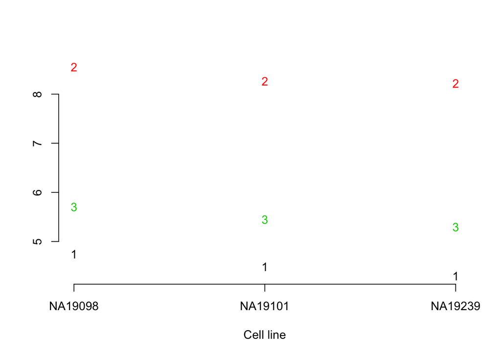

```r
library(matrixStats)
matplot(t(df_norm[which(index), 1:3]), type = "p", axes = F,
        xlab = "Cell line", ylab = "")
axis(1, at = c(1:3), labels = colnames(df_norm)[1:3] )
axis(2)
```

Consistent of gene adj-CVs before/after standardization.

```r
par(mfrow = c(1,2))
plot(x = df_cv[[1]], y = df_cv[[2]], main = "Adjusted log10 CV^2",
     xlab = "NA19238", ylab = "NA19101")
points(x = df_cv[[1]][1:10], y = df_cv[[2]][1:10], col = "red", cex = .8, pch = 16)
plot(x = df_norm[[1]], y = df_norm[[2]], main = "Adjusted log10 CV^2, standardized",
     xlab = "NA19238", ylab = "NA19101")
points(x = df_norm[[1]][1:10], y = df_norm[[2]][1:10], col = "red", cex = .8, pch = 16)
```

[figure not shown]

Compute distance

```r
library(matrixStats)
df_norm$squared_dev <- rowSums( ( df_norm - rowMedians(as.matrix(df_norm)) )^2 )
df_norm$abs_dev <- rowSums(abs( df_norm - rowMedians(as.matrix(df_norm)) ))
```

## Permutation-based reuslts

```r
source("../code/permute-cells.r")
permuted_data <- permute_cells(log2counts = molecules_ENSG,
                               grouping_vector = anno_qc_filter$individual,
                               num_permute = 10)
save(permuted_data, file = "rda/permuted_data.rda")
```